# Biostat 212A Homework 3

Due Feb 20, 2024 @ 11:59PM

Author

Li Zhang 206305918

Published

February 20, 2024

## 1 ISL Exercise 5.4.2 (10pts)

$$P = 1 - \frac{1}{n}$$

There are n observations in the sample, and we’re sampling with replacement, so the probability of selecting any specific observation is $1/n$. The probability of not selecting that observation is $1 - 1/n$(the probability the 1st bootstrap observation is not the jth observation).

2. $$P = 1 - \frac{1}{n}$$

According to (a), the probability of the i-th bootstrap observation (where i ranges from 1 to n) differs from the j-th observation in the original sample is $1 - 1/n$.we can proceed with a multiplication:

$$P = (1 - \frac{1}{n})^n$$

n = 5
$$P = 1 - (1 - \frac{1}{n})^n = 1 - (1 - \frac{1}{5})^5 = 0.67232$$

n = 100
$$P = 1 - (1 - \frac{1}{n})^n = 1 - (1 - \frac{1}{100})^{100} = 0.63397$$

n = 10000
$$P = 1 - (1 - \frac{1}{n})^n = 1 - (1 - \frac{1}{10000})^{10000} = 0.63214$$

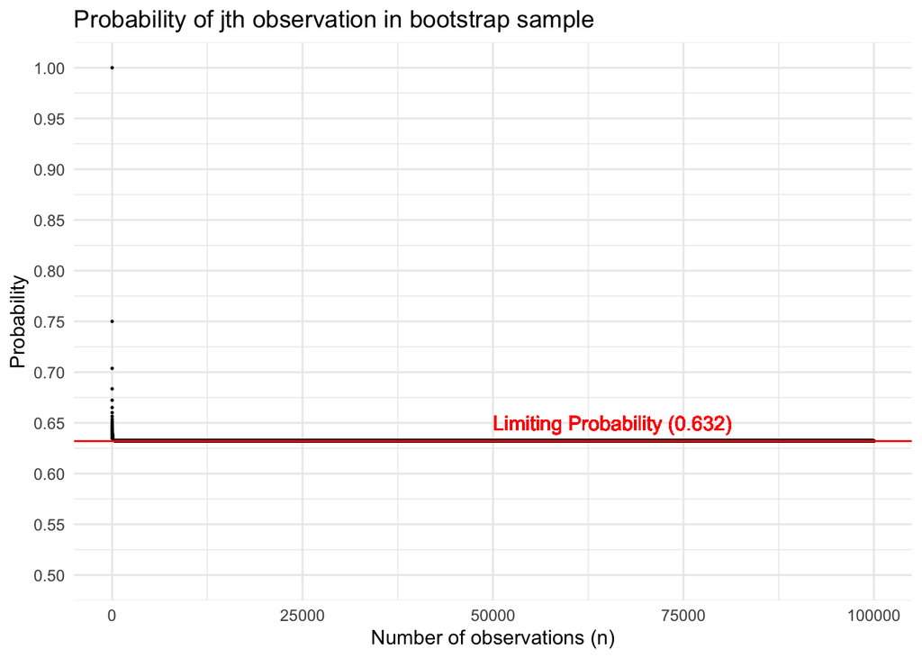

```r
library(ggplot2)

# Initialize data frame
df <- data.frame(n_values = 1:100000)

# Calculate probabilities for each n
df$probabilities <- 1 - (1 - 1/df$n_values)^df$n_values

# Create the plot
ggplot(df, aes(x = n_values, y = probabilities)) +
  geom_point(size = 0.5, shape = 20) +
  geom_hline(yintercept = 0.632, color = "red") +
  geom_text(x = 50000, y = 0.65, label = "Limiting Probability (0.632)", color = "red", hjust = 0) +
  labs(x = "Number of observations (n)", y = "Probability",
       title = "Probability of jth observation in bootstrap sample") +
  scale_y_continuous(limits = c(0.5, 1), breaks = seq(0, 1, by = 0.05)) +
  theme_minimal()
```

- As the number of observations (n) increases, the probability approaches a limiting value around 0.632.
- The plot demonstrates the convergence of the probability to the limiting value as n grows.
- Initially, for smaller values of n, the probability varies more widely, but as n increases, the variability decreases, and the probability stabilizes around the limiting value.

```r
store <- rep(NA, 10000)

for (i in 1:10000) {
  store[i] <- sum(sample(1:100, rep = TRUE) == 4) > 0
}

mean(store)
```

```
[1] 0.6361
```

## 2 ISL Exercise 5.4.9 (20pts)

```r
library(ISLR2)
mean(Boston$medv)
```

```
[1] 22.53281
```

```r
se_mu_hat <- sd(Boston$medv) / sqrt(length(Boston$medv))
se_mu_hat
```

```
[1] 0.4088611
```

The standard error of $\hat{\mu}$ represents the variability of sample means that we would expect if we were to repeatedly sample from the population.

It suggests that, on average, the sample mean estimate could deviate from the true population mean by approximately 0.4088611 units.

```r
boot.fn <- function(data, index){
  X <- data$medv[index]
  mu <- mean(X)
  return(mu)
}
```

```r
library(boot)
boot(Boston, boot.fn, R = 1000)
```

```
ORDINARY NONPARAMETRIC BOOTSTRAP


Call:
boot(data = Boston, statistic = boot.fn, R = 1000)


Bootstrap Statistics :
    original        bias    std. error
t1* 22.53281 -4.881423e-05   0.4164701
```

The slight difference obtained from these two methods arises from their distinct computation approaches.

The calculation of the standard error of the mean in part (b) is **based on the classic formula** of dividing the sample standard deviation by the square root of the sample size. The premise of this formula is that the sample data are drawn from a population that follows a normal distribution, and the sample size is sufficiently large to satisfy the central limit theorem.

On the other hand, the standard error obtained through the bootstrap method is estimated by **repeatedly sampling from the sample data**, which allows for a more accurate assessment of the uncertainty in the sample data’s distribution and parameters.

```r
t.test(Boston$medv)
```

```
    One Sample t-test

data:  Boston$medv
t = 55.111, df = 505, p-value < 2.2e-16
alternative hypothesis: true mean is not equal to 0
95 percent confidence interval:
 21.72953 23.33608
sample estimates:
mean of x
 22.53281
```

Using the t.test function, we can obtain a 95% confidence interval for the mean of medv, which is (21.72953, 23.33608).

```r
c(mean(Boston$medv) - 2 * 0.413, mean(Boston$medv) + 2 * 0.413)
```

```
[1] 21.70681 23.35881
```

```r
median(Boston$medv)
```

```
[1] 21.2
```

```r
boot.fn2 <- function(data, index){
  X <- data$medv[index]
  median <- median(X)
  return(median)
}
```

```r
boot(Boston, boot.fn2, R = 1000)
```

```
ORDINARY NONPARAMETRIC BOOTSTRAP


Call:
boot(data = Boston, statistic = boot.fn2, R = 1000)


Bootstrap Statistics :
    original  bias    std. error
t1*     21.2  -1e-04   0.3823103
```

It provides a reliable estimate of the standard error of the median, allowing for more robust statistical inference.

```r
quantile(Boston$medv, 0.1)
```

```
  10%
12.75
```

$\hat{\mu}_{0.1}$ = 12.75

```r
boot.fn3 <- function(data, index){
  X <- data$medv[index]
  Y <- quantile(X, 0.1)
  return(Y)
}
```

```r
boot(Boston, boot.fn3, R = 1000)
```

```
ORDINARY NONPARAMETRIC BOOTSTRAP


Call:
boot(data = Boston, statistic = boot.fn3, R = 1000)


Bootstrap Statistics :
    original  bias    std. error
t1*    12.75 0.01285   0.4874371
```

This indicates that the computed 10th percentile value is likely to be close to the true population value, with relatively little variability due to sampling.

## 3 Least squares is MLE (10pts)

Show that in the case of linear model with Gaussian errors, maximum likelihood and least squares are the same thing, and $C_p$ and AIC are equivalent.

Consider a linear model with Gaussian errors:

$$y = X\beta + \epsilon, \quad \epsilon \sim N(0, \sigma^2)$$
The likelihood function is:

$$L(\beta, \sigma^2) = \prod_{i=1}^n \frac{1}{\sqrt{2\pi\sigma^2}} \exp\left(-\frac{(y_i - x_i^T\beta)^2}{2\sigma^2}\right)$$
The log-likelihood function is:
$$\ell(\beta, \sigma^2) = -\frac{n}{2} \log(2\pi) - \frac{n}{2} \log(\sigma^2) - \frac{1}{2\sigma^2} \sum_{i=1}^n (y_i - x_i^T\beta)^2$$
$$$\ell(\beta, \sigma^2) = -\frac{n}{2}\log\sigma^2 - \frac{1}{2\sigma^2}(y-X\beta)^T(y-X\beta)$$$

The maximum likelihood estimate of $\beta$ is the value that maximizes the log-likelihood function. This is equivalent to minimizing the sum of squared errors:

$$\hat{\beta} = \arg\min_{\beta} \sum_{i=1}^n (y_i - x_i^T\beta)^2$$
Therefore, maximum likelihood estimation is equivalent to least squares in this case.

Mallow’s $C_p$:

$$C_p = \frac{1}{n} (\text{RSS} + 2d \hat{\sigma}^2),$$
where $d$ is the total number of parameters used and $\hat{\sigma}^2$ is an estimate of the error variance $\text{Var}(\epsilon)$. Smaller $C_p$ means better model.

The AIC criterion:

$$\text{AIC} = - 2 \log L + 2d,$$
where $L$ is the maximized value of the likelihood function for the estimated model. Smaller AIC means better model.

From least squares estimation, we have:

$$\hat{\beta} = (X^TX)^{-1}X^Ty$$
The residual sum of squares is:

$$\text{RSS} = (y - X\hat{\beta})^T(y - X\hat{\beta}) = y^Ty - y^TX(X^TX)^{-1}X^Ty$$
Plugging the above into the expressions for AIC gives:

$$\text{AIC} = -2[\ell(\hat{\beta}, \hat{\sigma}^2) - \frac{n}{2}\log(2\pi)] + 2d$$
Since $\hat{\sigma}^2 = \frac{RSS}{n}$, it can be shown that Cp and AIC are equivalent formulas under Gaussian errors.

## 4 ISL Exercise 6.6.1 (10pts)

Best subset has the smallest training RSS because it considers all possible models and selects the one with the smallest RSS.

Any of the models can have the smallest test RSS.

1. True.
2. True.
3. False. The predictors selected by forward and backward stepwise are not necessarily subsets of each other.
4. False. Same reason as iii.
5. False.

## 5 ISL Exercise 6.6.3 (10pts)

**iv. Steadily decrease.** As we raise $s$ from 0, we are imposing fewer restrictions on the $\beta_j$ coefficients (ultimately approaching their least squares estimates), resulting in a progressively more flexible model. This leads to a consistent decrease in the training RSS.

**ii. Decrease initially, and then eventually start increasing in a U shape.** As the flexibility of the model increases, the performance of the model may improve on the training data, but it may be overfitted on the test data, causing the test RSS to start increasing.

**iii. Steadily increase.** As the flexibility of the model increases, the model becomes more sensitive to detail and noise in the training data, which leads to an increase in the variance of the model.

**iv. Steadily decrease.** The model is more flexbile, so the bias will decrease.

**v. Remain constant.** By definition, the irreducible error is the error that cannot be reduced by any model. Therefore, it remains constant regardless of the model’s flexibility.

## 6 ISL Exercise 6.6.4 (10pts)

**iii. Steadily increase.** As we increase $\lambda$ from 0, we are imposing more restrictions on the $\beta_j$ coefficients, resulting in a progressively less flexible model. This leads to a consistent increase in the training RSS.

**ii. Decrease initially, and then eventually start increasing in a U shape.** As the flexibility of the model decreases, the performance of the model may improve on the training data, but it may be underfitted on the test data when $\lambda$ increases beyond the point, causing the test RSS to start increasing.

**iv. Steadily decrease.** As the flexibility of the model decreases, the model becomes less sensitive to detail and noise in the training data, which leads to a decrease in the variance of the model.

**iii. Steadily increase.** The model is less flexible, so the bias will increase.

**v. Remain constant.** By definition, the irreducible error is the error that cannot be reduced by any model. Therefore, it remains constant regardless of the model’s flexibility.

## 7 ISL Exercise 6.6.5 (10pts)

We need to optimize:

$$(y_1 - \hat{\beta_1}x_{11} - \hat{\beta_2}x_{12})^2 + (y_2 - \hat{\beta_1}x_{21} - \hat{\beta_2}x_{22})^2 + \lambda(\hat{\beta_1}^2 + \hat{\beta_2}^2)$$

Suppose $x_{11} = x_{12} = - x_{21} = - x_{22} = a$ and $y_1 = - y_2 = b$,then we need to optimize:

$$(b - \hat{\beta_1}a - \hat{\beta_2}a)^2 + (b + \hat{\beta_1}a + \hat{\beta_2}a)^2 + \lambda(\hat{\beta_1}^2 + \hat{\beta_2}^2) = 2[b - a(\hat{\beta_1} + \hat{\beta_2})]^2 + \lambda(\hat{\beta_1}^2 + \hat{\beta_2}^2)$$
Take the partial derivative of the above expression with respect to $\hat{\beta_1}$ and $\hat{\beta_2}$, and set them to 0.

$$\frac{\partial}{\partial \hat{\beta_1}} = 4a[b - a(\hat{\beta_1} + \hat{\beta_2})] + 2\lambda\hat{\beta_1} = 0$$
$$\frac{\partial}{\partial \hat{\beta_2}} = 4a[b - a(\hat{\beta_1} + \hat{\beta_2})] + 2\lambda\hat{\beta_2} = 0$$
Solving the above equations, we get: $\hat{\beta_1} = \hat{\beta_2} = \frac{b}{2a(1 + \frac{\lambda}{2a})}$

The lasso optimization problem:

$$(y_1 - \beta_1x_{11} - \beta_2x_{12})^2 + (y_2 - \beta_1x_{21} - \beta_2x_{22})^2 + \lambda(|\beta_1| + |\beta_2|)$$

Similarly, we need to optimize:

$$(b - \beta_1a - \beta_2a)^2 + (b + \beta_1a + \beta_2a)^2 + \lambda(|\beta_1| + |\beta_2|) = 2[b - a(\beta_1 + \beta_2)]^2 + \lambda(|\beta_1| + |\beta_2|)$$
Take the partial derivative of the above expression with respect to $\beta_1$ and $\beta_2$, and set them to 0.

$$\frac{\partial}{\partial \beta_1} = 4a[b - a(\beta_1 + \beta_2)] + \lambda\text{sign}(\beta_1) = 0$$
$$\frac{\partial}{\partial \beta_2} = 4a[b - a(\beta_1 + \beta_2)] + \lambda\text{sign}(\beta_2) = 0$$
Solving the above equations, we get:

$$\frac{|\hat{\beta_1}|}{\hat{\beta_1}} = \frac{|\hat{\beta_2}|}{\hat{\beta_2}} = \frac{b - \frac{a\lambda}{2}}{2a}$$

So the lasso coefficients $\hat{\beta_1}$ and $\hat{\beta_2}$ are not unique – in other words, there are many possible solutions to the optimization problem in (c).

## 8 ISL Exercise 6.6.11 (30pts)

You must follow the [typical machine learning paradigm](https://ucla-biostat-212a.github.io/2024winter/slides/06-modelselection/workflow_lasso.html) to compare *at least* 3 methods: least squares, lasso, and ridge. Report final results as

| Method | CV RMSE | Test RMSE |  |
| --- | --- | --- | --- |
| LS |  |  |  |
| Ridge |  |  |  |
| Lasso |  |  |  |
| … |  |  |  |

```r
library(MASS)
library(GGally)
library(ISLR2)
library(tidymodels)
library(tidyverse)

Boston <- as_tibble(Boston) %>% print(width = Inf)
```

```
# A tibble: 506 × 14
      crim    zn indus  chas   nox    rm   age   dis   rad   tax ptratio black
     <dbl> <dbl> <dbl> <int> <dbl> <dbl> <dbl> <dbl> <int> <dbl>   <dbl> <dbl>
 1 0.00632  18    2.31     0 0.538  6.58  65.2  4.09     1   296    15.3  397.
 2 0.0273    0    7.07     0 0.469  6.42  78.9  4.97     2   242    17.8  397.
 3 0.0273    0    7.07     0 0.469  7.18  61.1  4.97     2   242    17.8  393.
 4 0.0324    0    2.18     0 0.458  7.00  45.8  6.06     3   222    18.7  395.
 5 0.0690    0    2.18     0 0.458  7.15  54.2  6.06     3   222    18.7  397.
 6 0.0298    0    2.18     0 0.458  6.43  58.7  6.06     3   222    18.7  394.
 7 0.0883   12.5  7.87     0 0.524  6.01  66.6  5.56     5   311    15.2  396.
 8 0.145    12.5  7.87     0 0.524  6.17  96.1  5.95     5   311    15.2  397.
 9 0.211    12.5  7.87     0 0.524  5.63 100    6.08     5   311    15.2  387.
10 0.170    12.5  7.87     0 0.524  6.00  85.9  6.59     5   311    15.2  387.
   lstat  medv
   <dbl> <dbl>
 1  4.98  24
 2  9.14  21.6
 3  4.03  34.7
 4  2.94  33.4
 5  5.33  36.2
 6  5.21  28.7
 7 12.4   22.9
 8 19.2   27.1
 9 29.9   16.5
10 17.1   18.9
# ℹ 496 more rows
```

```r
# Numerical summaries
summary(Boston)
```

```
      crim                zn             indus            chas
 Min.   : 0.00632   Min.   :  0.00   Min.   : 0.46   Min.   :0.00000
 1st Qu.: 0.08205   1st Qu.:  0.00   1st Qu.: 5.19   1st Qu.:0.00000
 Median : 0.25651   Median :  0.00   Median : 9.69   Median :0.00000
 Mean   : 3.61352   Mean   : 11.36   Mean   :11.14   Mean   :0.06917
 3rd Qu.: 3.67708   3rd Qu.: 12.50   3rd Qu.:18.10   3rd Qu.:0.00000
 Max.   :88.97620   Max.   :100.00   Max.   :27.74   Max.   :1.00000
      nox               rm             age              dis
 Min.   :0.3850   Min.   :3.561   Min.   :  2.90   Min.   : 1.130
 1st Qu.:0.4490   1st Qu.:5.886   1st Qu.: 45.02   1st Qu.: 2.100
 Median :0.5380   Median :6.208   Median : 77.50   Median : 3.207
 Mean   :0.5547   Mean   :6.285   Mean   : 68.57   Mean   : 3.795
 3rd Qu.:0.6240   3rd Qu.:6.623   3rd Qu.: 94.08   3rd Qu.: 5.188
 Max.   :0.8710   Max.   :8.780   Max.   :100.00   Max.   :12.127
      rad              tax           ptratio          black
 Min.   : 1.000   Min.   :187.0   Min.   :12.60   Min.   :  0.32
 1st Qu.: 4.000   1st Qu.:279.0   1st Qu.:17.40   1st Qu.:375.38
 Median : 5.000   Median :330.0   Median :19.05   Median :391.44
 Mean   : 9.549   Mean   :408.2   Mean   :18.46   Mean   :356.67
 3rd Qu.:24.000   3rd Qu.:666.0   3rd Qu.:20.20   3rd Qu.:396.23
 Max.   :24.000   Max.   :711.0   Max.   :22.00   Max.   :396.90
     lstat            medv
 Min.   : 1.73   Min.   : 5.00
 1st Qu.: 6.95   1st Qu.:17.02
 Median :11.36   Median :21.20
 Mean   :12.65   Mean   :22.53
 3rd Qu.:16.95   3rd Qu.:25.00
 Max.   :37.97   Max.   :50.00
```

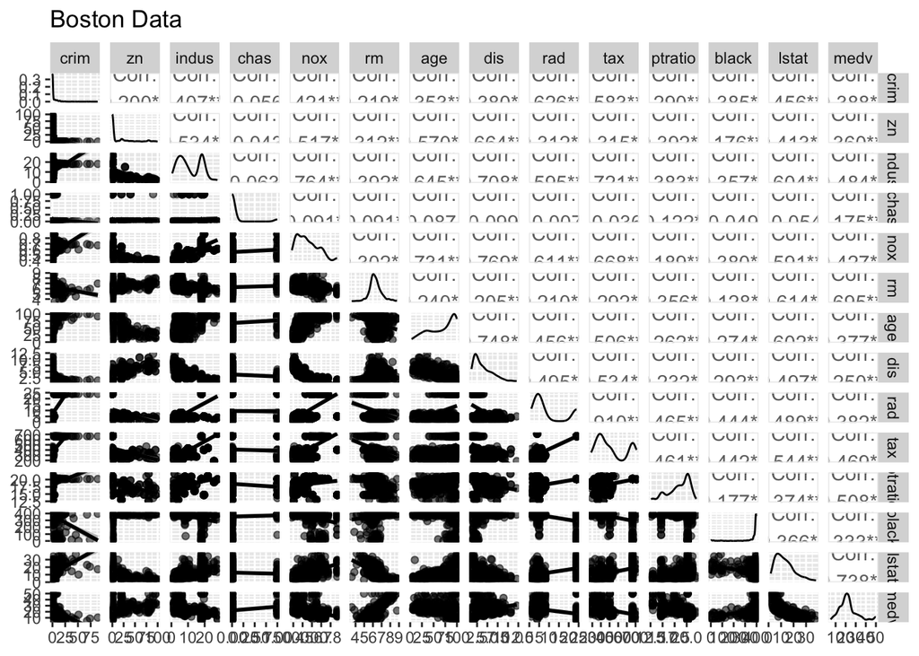

```r
# Graphical summaries
ggpairs(
  data = Boston,
  mapping = aes(alpha = 0.25),
  lower = list(continuous = "smooth")
  ) +
  labs(title = "Boston Data")
```

```r
Boston <- Boston %>%
  drop_na()
dim(Boston)
```

```
[1] 506  14
```

```r
sum(is.na(Boston))
```

```
[1] 0
```

After dropping ’NA’s, we are left with 506 data points.

- Initial split into test and non-test sets

```r
# For reproducibility
set.seed(425)
data_split <- initial_split(
  Boston,
  prop = 0.75
)

Boston_other <- training(data_split)
dim(Boston_other)
```

```
[1] 379  14
```

```r
Boston_test <- testing(data_split)
dim(Boston_test)
```

```
[1] 127  14
```

- Recipe

```r
norm_recipe <-
  recipe(
    crim ~ .,
    data = Boston_other
  ) %>%
  # create traditional dummy variables
  step_dummy(all_nominal()) %>%
  # zero-variance filter
  step_zv(all_predictors()) %>%
  # center and scale numeric data
  step_normalize(all_predictors()) %>%
  # step_log(Salary, base = 10) %>%
  # estimate the means and standard deviations
  prep(training = Boston_other, retain = TRUE)
norm_recipe
```

[output not shown]

**lasso**

```r
lasso_mod <-
    # mixture = 0 (ridge), mixture = 1 (lasso)
  linear_reg(penalty = tune(), mixture = 1) %>%
  set_engine("glmnet")
lasso_mod
```

```
Linear Regression Model Specification (regression)

Main Arguments:
  penalty = tune()
  mixture = 1

Computational engine: glmnet
```

**ridge**

```r
ridge_mod <-
  # mixture = 0 (ridge), mixture = 1 (lasso)
  linear_reg(penalty = tune(), mixture = 0) %>%
  set_engine("glmnet")
ridge_mod
```

```
Linear Regression Model Specification (regression)

Main Arguments:
  penalty = tune()
  mixture = 0

Computational engine: glmnet
```

**least squares**

```r
lm_mod <-
  linear_reg() %>%
  set_engine("lm")
lm_mod
```

```
Linear Regression Model Specification (regression)

Computational engine: lm
```

- Workflow

**lasso**

```r
lr_wf <-
  workflow() %>%
  add_model(lasso_mod) %>%
  add_recipe(norm_recipe)
lr_wf
```

```
══ Workflow ════════════════════════════════════════════════════════════════════
Preprocessor: Recipe
Model: linear_reg()

── Preprocessor ────────────────────────────────────────────────────────────────
3 Recipe Steps

• step_dummy()
• step_zv()
• step_normalize()

── Model ───────────────────────────────────────────────────────────────────────
Linear Regression Model Specification (regression)

Main Arguments:
  penalty = tune()
  mixture = 1

Computational engine: glmnet
```

**ridge**

```r
rr_wf <-
  workflow() %>%
  add_model(ridge_mod) %>%
  add_recipe(norm_recipe)
rr_wf
```

```
══ Workflow ════════════════════════════════════════════════════════════════════
Preprocessor: Recipe
Model: linear_reg()

── Preprocessor ────────────────────────────────────────────────────────────────
3 Recipe Steps

• step_dummy()
• step_zv()
• step_normalize()

── Model ───────────────────────────────────────────────────────────────────────
Linear Regression Model Specification (regression)

Main Arguments:
  penalty = tune()
  mixture = 0

Computational engine: glmnet
```

**least squares**

```r
ls_wf <-
  workflow() %>%
  add_model(lm_mod) %>%
  add_recipe(norm_recipe)
ls_wf
```

```
══ Workflow ════════════════════════════════════════════════════════════════════
Preprocessor: Recipe
Model: linear_reg()

── Preprocessor ────────────────────────────────────────────────────────────────
3 Recipe Steps

• step_dummy()
• step_zv()
• step_normalize()

── Model ───────────────────────────────────────────────────────────────────────
Linear Regression Model Specification (regression)

Computational engine: lm
```

- Tuning grid

Set up the grid for tuning in the range of $10^{-2}-10^3$.

```r
lambda_grid <-
  grid_regular(penalty(range = c(-2, 3), trans = log10_trans()), levels = 100)
lambda_grid
```

```
# A tibble: 100 × 1
   penalty
     <dbl>
 1  0.01
 2  0.0112
 3  0.0126
 4  0.0142
 5  0.0159
 6  0.0179
 7  0.0201
 8  0.0226
 9  0.0254
10  0.0285
# ℹ 90 more rows
```

- Cross-validation

Set cross-validation partitions.

```r
set.seed(111)
folds <- vfold_cv(Boston_other, v = 10)
folds
```

```
#  10-fold cross-validation
# A tibble: 10 × 2
   splits           id
   <list>           <chr>
 1 <split [341/38]> Fold01
 2 <split [341/38]> Fold02
 3 <split [341/38]> Fold03
 4 <split [341/38]> Fold04
 5 <split [341/38]> Fold05
 6 <split [341/38]> Fold06
 7 <split [341/38]> Fold07
 8 <split [341/38]> Fold08
 9 <split [341/38]> Fold09
10 <split [342/37]> Fold10
```

Fit cross-validation.

**lasso**

```r
lasso_fit <-
  lr_wf %>%
  tune_grid(
    resamples = folds,
    grid = lambda_grid
    )
lasso_fit
```

```
# Tuning results
# 10-fold cross-validation
# A tibble: 10 × 4
   splits           id     .metrics           .notes
   <list>           <chr>  <list>             <list>
 1 <split [341/38]> Fold01 <tibble [200 × 5]> <tibble [1 × 3]>
 2 <split [341/38]> Fold02 <tibble [0 × 5]>   <NULL>
 3 <split [341/38]> Fold03 <tibble [0 × 5]>   <NULL>
 4 <split [341/38]> Fold04 <tibble [0 × 5]>   <NULL>
 5 <split [341/38]> Fold05 <tibble [0 × 5]>   <NULL>
 6 <split [341/38]> Fold06 <tibble [0 × 5]>   <NULL>
 7 <split [341/38]> Fold07 <tibble [0 × 5]>   <NULL>
 8 <split [341/38]> Fold08 <tibble [0 × 5]>   <NULL>
 9 <split [341/38]> Fold09 <tibble [0 × 5]>   <NULL>
10 <split [342/37]> Fold10 <tibble [0 × 5]>   <NULL>

There were issues with some computations:

  - Warning(s) x1: A correlation computation is required, but `estimate` is constant...

Run `show_notes(.Last.tune.result)` for more information.
```

**ridge**

```r
ridge_fit <-
  rr_wf %>%
  tune_grid(
    resamples = folds,
    grid = lambda_grid
    )
ridge_fit
```

```
# Tuning results
# 10-fold cross-validation
# A tibble: 10 × 4
   splits           id     .metrics           .notes
   <list>           <chr>  <list>             <list>
 1 <split [341/38]> Fold01 <tibble [200 × 5]> <tibble [0 × 3]>
 2 <split [341/38]> Fold02 <tibble [200 × 5]> <tibble [0 × 3]>
 3 <split [341/38]> Fold03 <tibble [200 × 5]> <tibble [0 × 3]>
 4 <split [341/38]> Fold04 <tibble [200 × 5]> <tibble [0 × 3]>
 5 <split [341/38]> Fold05 <tibble [200 × 5]> <tibble [0 × 3]>
 6 <split [341/38]> Fold06 <tibble [200 × 5]> <tibble [0 × 3]>
 7 <split [341/38]> Fold07 <tibble [200 × 5]> <tibble [0 × 3]>
 8 <split [341/38]> Fold08 <tibble [200 × 5]> <tibble [0 × 3]>
 9 <split [341/38]> Fold09 <tibble [200 × 5]> <tibble [0 × 3]>
10 <split [342/37]> Fold10 <tibble [200 × 5]> <tibble [0 × 3]>
```

```r
ls_fit <-
  lr_wf %>%
  tune_grid(
    resamples = folds
    )
ls_fit
```

```
# Tuning results
# 10-fold cross-validation
# A tibble: 10 × 4
   splits           id     .metrics          .notes
   <list>           <chr>  <list>            <list>
 1 <split [341/38]> Fold01 <tibble [20 × 5]> <tibble [0 × 3]>
 2 <split [341/38]> Fold02 <tibble [20 × 5]> <tibble [0 × 3]>
 3 <split [341/38]> Fold03 <tibble [20 × 5]> <tibble [0 × 3]>
 4 <split [341/38]> Fold04 <tibble [20 × 5]> <tibble [0 × 3]>
 5 <split [341/38]> Fold05 <tibble [20 × 5]> <tibble [0 × 3]>
 6 <split [341/38]> Fold06 <tibble [20 × 5]> <tibble [0 × 3]>
 7 <split [341/38]> Fold07 <tibble [20 × 5]> <tibble [0 × 3]>
 8 <split [341/38]> Fold08 <tibble [20 × 5]> <tibble [0 × 3]>
 9 <split [341/38]> Fold09 <tibble [20 × 5]> <tibble [0 × 3]>
10 <split [342/37]> Fold10 <tibble [20 × 5]> <tibble [0 × 3]>
```

Visualize CV criterion.

**lasso**

```
# A tibble: 200 × 7
   penalty .metric .estimator  mean     n std_err .config
     <dbl> <chr>   <chr>      <dbl> <int>   <dbl> <chr>
 1  0.01   rmse    standard   3.45      1      NA Preprocessor1_Model001
 2  0.01   rsq     standard   0.732     1      NA Preprocessor1_Model001
 3  0.0112 rmse    standard   3.45      1      NA Preprocessor1_Model002
 4  0.0112 rsq     standard   0.732     1      NA Preprocessor1_Model002
 5  0.0126 rmse    standard   3.45      1      NA Preprocessor1_Model003
 6  0.0126 rsq     standard   0.732     1      NA Preprocessor1_Model003
 7  0.0142 rmse    standard   3.44      1      NA Preprocessor1_Model004
 8  0.0142 rsq     standard   0.732     1      NA Preprocessor1_Model004
 9  0.0159 rmse    standard   3.44      1      NA Preprocessor1_Model005
10  0.0159 rsq     standard   0.732     1      NA Preprocessor1_Model005
# ℹ 190 more rows
```

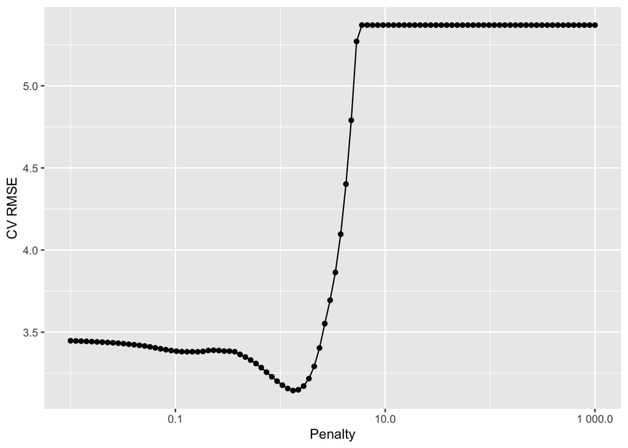

```r
lasso_fit %>%
  collect_metrics() %>%
  print(width = Inf) %>%
  filter(.metric == "rmse") %>%
  ggplot(mapping = aes(x = penalty, y = mean)) +
  geom_point() +
  geom_line() +
  labs(x = "Penalty", y = "CV RMSE") +
  scale_x_log10(labels = scales::label_number())
```

**ridge**

```
# A tibble: 200 × 7
   penalty .metric .estimator  mean     n std_err .config
     <dbl> <chr>   <chr>      <dbl> <int>   <dbl> <chr>
 1  0.01   rmse    standard   6.01     10  1.14   Preprocessor1_Model001
 2  0.01   rsq     standard   0.558    10  0.0538 Preprocessor1_Model001
 3  0.0112 rmse    standard   6.01     10  1.14   Preprocessor1_Model002
 4  0.0112 rsq     standard   0.558    10  0.0538 Preprocessor1_Model002
 5  0.0126 rmse    standard   6.01     10  1.14   Preprocessor1_Model003
 6  0.0126 rsq     standard   0.558    10  0.0538 Preprocessor1_Model003
 7  0.0142 rmse    standard   6.01     10  1.14   Preprocessor1_Model004
 8  0.0142 rsq     standard   0.558    10  0.0538 Preprocessor1_Model004
 9  0.0159 rmse    standard   6.01     10  1.14   Preprocessor1_Model005
10  0.0159 rsq     standard   0.558    10  0.0538 Preprocessor1_Model005
# ℹ 190 more rows
```

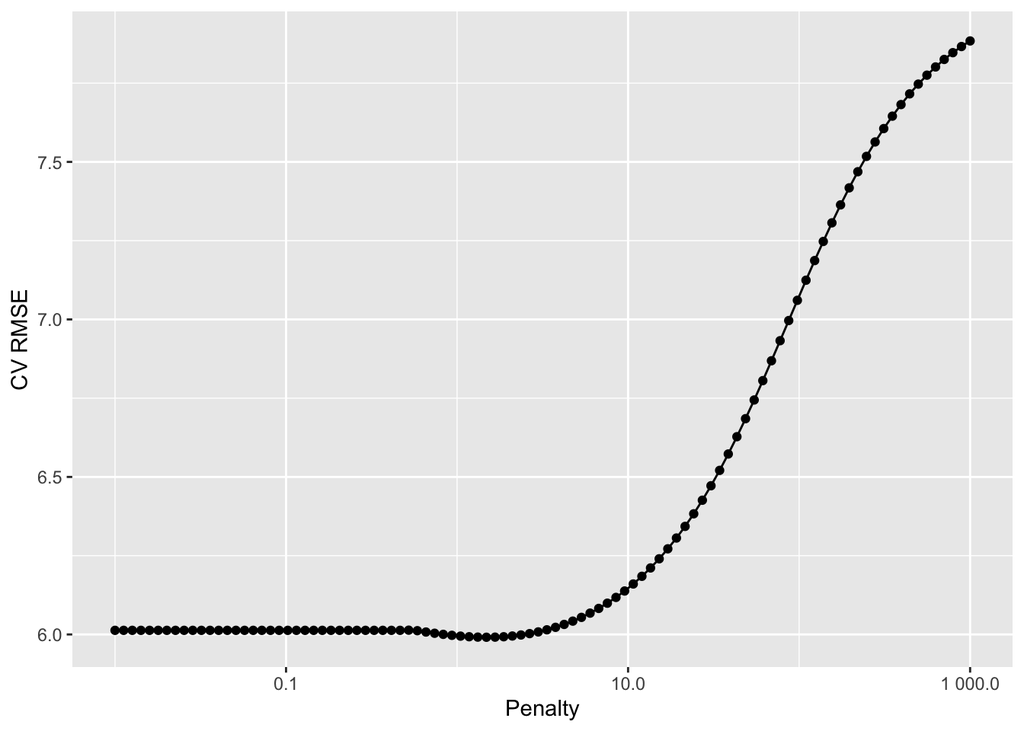

```r
ridge_fit %>%
  collect_metrics() %>%
  print(width = Inf) %>%
  filter(.metric == "rmse") %>%
  ggplot(mapping = aes(x = penalty, y = mean)) +
  geom_point() +
  geom_line() +
  labs(x = "Penalty", y = "CV RMSE") +
  scale_x_log10(labels = scales::label_number())
```

Show the top 5 models ($\lambda$ values)

**lasso**

```r
lasso_fit %>%
  show_best("rmse")
```

```
# A tibble: 5 × 7
  penalty .metric .estimator  mean     n std_err .config
    <dbl> <chr>   <chr>      <dbl> <int>   <dbl> <chr>
1    1.32 rmse    standard    3.14     1      NA Preprocessor1_Model043
2    1.48 rmse    standard    3.15     1      NA Preprocessor1_Model044
3    1.18 rmse    standard    3.16     1      NA Preprocessor1_Model042
4    1.67 rmse    standard    3.17     1      NA Preprocessor1_Model045
5    1.05 rmse    standard    3.18     1      NA Preprocessor1_Model041
```

**ridge**

```r
ridge_fit %>%
  show_best("rmse")
```

```
# A tibble: 5 × 7
  penalty .metric .estimator  mean     n std_err .config
    <dbl> <chr>   <chr>      <dbl> <int>   <dbl> <chr>
1    1.48 rmse    standard    5.99    10    1.17 Preprocessor1_Model044
2    1.67 rmse    standard    5.99    10    1.17 Preprocessor1_Model045
3    1.32 rmse    standard    5.99    10    1.17 Preprocessor1_Model043
4    1.87 rmse    standard    5.99    10    1.18 Preprocessor1_Model046
5    1.18 rmse    standard    5.99    10    1.16 Preprocessor1_Model042
```

Let’s select the best model

**lasso**

```r
best_lasso <- lasso_fit %>%
  select_best("rmse")
best_lasso
```

```
# A tibble: 1 × 2
  penalty .config
    <dbl> <chr>
1    1.32 Preprocessor1_Model043
```

**ridge**

```r
best_ridge <- ridge_fit %>%
  select_best("rmse")
best_ridge
```

```
# A tibble: 1 × 2
  penalty .config
    <dbl> <chr>
1    1.48 Preprocessor1_Model044
```

- Final model

**lasso**

```r
# Final workflow
final_wf_lasso <- lr_wf %>%
  finalize_workflow(best_lasso)
final_wf_lasso
```

```
══ Workflow ════════════════════════════════════════════════════════════════════
Preprocessor: Recipe
Model: linear_reg()

── Preprocessor ────────────────────────────────────────────────────────────────
3 Recipe Steps

• step_dummy()
• step_zv()
• step_normalize()

── Model ───────────────────────────────────────────────────────────────────────
Linear Regression Model Specification (regression)

Main Arguments:
  penalty = 1.32194114846603
  mixture = 1

Computational engine: glmnet
```

```r
# Fit the whole training set, then predict the test cases
final_fit_lasso <-
  final_wf_lasso %>%
  last_fit(data_split)
final_fit_lasso
```

```
# Resampling results
# Manual resampling
# A tibble: 1 × 6
  splits            id               .metrics .notes   .predictions .workflow
  <list>            <chr>            <list>   <list>   <list>       <list>
1 <split [379/127]> train/test split <tibble> <tibble> <tibble>     <workflow>
```

```r
# Test metrics
final_fit_lasso %>% collect_metrics()
```

```
# A tibble: 2 × 4
  .metric .estimator .estimate .config
  <chr>   <chr>          <dbl> <chr>
1 rmse    standard       5.66  Preprocessor1_Model1
2 rsq     standard       0.511 Preprocessor1_Model1
```

**Ridge**

```r
# Final workflow
final_wf_ridge <- rr_wf %>%
  finalize_workflow(best_ridge)
final_wf_ridge
```

```
══ Workflow ════════════════════════════════════════════════════════════════════
Preprocessor: Recipe
Model: linear_reg()

── Preprocessor ────────────────────────────────────────────────────────────────
3 Recipe Steps

• step_dummy()
• step_zv()
• step_normalize()

── Model ───────────────────────────────────────────────────────────────────────
Linear Regression Model Specification (regression)

Main Arguments:
  penalty = 1.48496826225447
  mixture = 0

Computational engine: glmnet
```

```r
# Fit the whole training set, then predict the test cases
final_fit_ridge <-
  final_wf_ridge %>%
  last_fit(data_split)
final_fit_ridge
```

```
# Resampling results
# Manual resampling
# A tibble: 1 × 6
  splits            id               .metrics .notes   .predictions .workflow
  <list>            <chr>            <list>   <list>   <list>       <list>
1 <split [379/127]> train/test split <tibble> <tibble> <tibble>     <workflow>
```

```r
# Test metrics
final_fit_ridge %>% collect_metrics()
```

```
# A tibble: 2 × 4
  .metric .estimator .estimate .config
  <chr>   <chr>          <dbl> <chr>
1 rmse    standard       5.38  Preprocessor1_Model1
2 rsq     standard       0.535 Preprocessor1_Model1
```

**Least Squares**

```r
# Fit the whole training set, then predict the test cases
final_fit_ls <-
  ls_wf %>%
  last_fit(data_split)
final_fit_ls
```

```
# Resampling results
# Manual resampling
# A tibble: 1 × 6
  splits            id               .metrics .notes   .predictions .workflow
  <list>            <chr>            <list>   <list>   <list>       <list>
1 <split [379/127]> train/test split <tibble> <tibble> <tibble>     <workflow>
```

```r
# Test metrics
final_fit_ls %>% collect_metrics()
```

```
# A tibble: 2 × 4
  .metric .estimator .estimate .config
  <chr>   <chr>          <dbl> <chr>
1 rmse    standard       5.45  Preprocessor1_Model1
2 rsq     standard       0.525 Preprocessor1_Model1
```

- Summary

**CV RMSE**

```r
lasso_cv_results <- lasso_fit %>%
   show_best("rmse")

lasso_cv_rmse <- lasso_cv_results %>%
  filter(.metric == "rmse") %>%
  arrange(mean) %>%
  slice(1) %>%
  select(mean)

lasso_cv_rmse
```

```
# A tibble: 1 × 1
   mean
  <dbl>
1  3.14
```

```r
ridge_cv_results <- ridge_fit %>%
   show_best("rmse")

ridge_cv_rmse <- ridge_cv_results %>%
  filter(.metric == "rmse") %>%
  arrange(mean) %>%
  slice(1) %>%
  select(mean)

ridge_cv_rmse
```

```
# A tibble: 1 × 1
   mean
  <dbl>
1  5.99
```

```r
ls_cv_rmse <- ls_fit %>%
  collect_metrics() %>%
  filter(.metric == "rmse") %>%
  summarise(mean_rmse = mean(mean))

ls_cv_rmse
```

```
# A tibble: 1 × 1
  mean_rmse
      <dbl>
1      6.07
```

**Test RMSE**

```r
lasso_test_rmse <- final_fit_lasso %>%
  collect_metrics() %>%
  filter(.metric == "rmse")

lasso_test_rmse
```

```
# A tibble: 1 × 4
  .metric .estimator .estimate .config
  <chr>   <chr>          <dbl> <chr>
1 rmse    standard        5.66 Preprocessor1_Model1
```

```r
ridge_test_rmse <- final_fit_ridge %>%
  collect_metrics() %>%
  filter(.metric == "rmse")

ridge_test_rmse
```

```
# A tibble: 1 × 4
  .metric .estimator .estimate .config
  <chr>   <chr>          <dbl> <chr>
1 rmse    standard        5.38 Preprocessor1_Model1
```

```r
ls_test_rmse <- final_fit_ls %>%
  collect_metrics() %>%
  filter(.metric == "rmse")

ls_test_rmse
```

```
# A tibble: 1 × 4
  .metric .estimator .estimate .config
  <chr>   <chr>          <dbl> <chr>
1 rmse    standard        5.45 Preprocessor1_Model1
```

- Comparison and conclusion

```r
library(dplyr)

cv_rmse_values <- c(lasso_cv_rmse$mean, ridge_cv_rmse$mean, ls_cv_rmse$mean_rmse)
test_rmse_values <- c(lasso_test_rmse$.estimate, ridge_test_rmse$.estimate, ls_test_rmse$.estimate)

results <- data.frame(
  method = c("lasso", "ridge", "least squares"),
  cv_rmse = cv_rmse_values,
  test_rmse = test_rmse_values
)

library(gt)
gt_results <- gt(results) %>%
  tab_header(
    title = "Comparison of CV RMSE and Test RMSE for Lasso, Ridge, and Least Squares"
  )

gt_results
```

Comparison of CV RMSE and Test RMSE for Lasso, Ridge, and Least Squares

[output not shown]

Considering both CV RMSE and Test RMSE,I will choose the ridge model, as it demonstrates good performance on unseen data.

## 9 Bonus question (20pts)

Consider a linear regression, fit by least squares to a set of training data $(x_1, y_1), \ldots, (x_N, y_N)$ drawn at random from a population. Let $\hat \beta$ be the least squares estimate. Suppose we have some test data $(\tilde{x}_1, \tilde{y}_1), \ldots, (\tilde{x}_M, \tilde{y}_M)$ drawn at random from the same population as the training data. If $R_{\text{train}}(\beta) = \frac{1}{N} \sum_{i=1}^N (y_i - \beta^T x_i)^2$ and $R_{\text{test}}(\beta) = \frac{1}{M} \sum_{i=1}^M (\tilde{y}_i - \beta^T \tilde{x}_i)^2$. Show that
$$\operatorname{E}[R_{\text{train}}(\hat{\beta})] < \operatorname{E}[R_{\text{test}}(\hat{\beta})].$$
Consider a linear regression model:

$$y = X\beta + \epsilon, \quad \epsilon \sim N(0, \sigma^2)$$
The least squares estimator is: $\hat{\beta} = (X^TX)^{-1}X^Ty$

Since they are from the same distribution, we have:

$$\frac{1}{N} \sum_{i=1}^N (y_i - \beta^T x_i)^2 = \frac{1}{M} \sum_{i=1}^M (y_i - \beta^T x_i)^2$$

So we now need to compare $\operatorname{E}[\frac{1}{N} \sum_{i=1}^N (y_i - \beta^T x_i)^2]$ and $\operatorname{E}[\frac{1}{N} \sum_{i=1}^N (\tilde{y}_i - \beta^T \tilde{x}_i)^2]$

First consider the random variables:

$$Z = \frac{1}{N} \sum_{i=1}^N (y_i - \hat\beta^T x_i)^2$$

$$W = \frac{1}{N} \sum_{i=1}^N (\tilde{y}_i - \tilde\beta^T \tilde{x}_i)^2$$

where $\tilde\beta$ is the least squares estimate for the test data.

W and Z have the same distribution because we assume that the training dataset and the testing dataset are both independently drawn from the same population, and the samples are also independent. So, $\operatorname{E}[Z] = \operatorname{E}[W]$

Now, recall that the coefficients estimated by least squares are chosen to minimize the sum of squared errors on the training data. This means that for any other set of coefficients, the sum of squared errors on the training data would be greater than or equal to the sum of squared errors obtained by the least squares coefficients.

Therefore, when using the coefficients obtained from the test data $\tilde{\beta}$, the sum of squared errors on the training data would be greater than or equal to the sum of squared errors obtained by the coefficients from the training data $\hat{\beta}$. This implies that the observed test error $W_{\text{observed}}$ would be greater than or equal to the expected test error represented by the random variable W.

$$W = \frac{1}{N} \sum_{i=1}^N (\tilde{y}_i - \tilde\beta^T \tilde{x}_i)^2 \leq \frac{1}{N} \sum_{i=1}^N (\tilde{y}_i - \hat\beta^T \tilde{x}_i)^2$$

So, we have:

$$\operatorname{E}[\frac{1}{N} \sum_{i=1}^N (y_i - \hat\beta^T x_i)^2] \leq \operatorname{E}[\frac{1}{N} \sum_{i=1}^N (\tilde{y}_i - \hat\beta^T \tilde{x}_i)^2]$$

So, we can conclude that:
$$\operatorname{E}[R_{\text{train}}(\hat{\beta})] \leq \operatorname{E}[R_{\text{test}}(\hat{\beta})].$$